# Eigen-decomposition and SVD

Biostat/Biomath M257

Author

Dr. Hua Zhou @ UCLA

Published

May 10, 2023

System information (for reproducibility):

```julia
versioninfo()
```

```
Julia Version 1.9.0
Commit 8e630552924 (2023-05-07 11:25 UTC)
Platform Info:
  OS: macOS (arm64-apple-darwin22.4.0)
  CPU: 12 × Apple M2 Max
  WORD_SIZE: 64
  LIBM: libopenlibm
  LLVM: libLLVM-14.0.6 (ORCJIT, apple-m1)
  Threads: 9 on 8 virtual cores
Environment:
  JULIA_NUM_THREADS = 8
  JULIA_EDITOR = code
```

Load packages:

```julia
using Pkg

Pkg.activate(pwd())
Pkg.instantiate()
Pkg.status()
```

[output not shown]

```
Status `~/Documents/github.com/ucla-biostat-257/2023spring/slides/20-eigsvd/Project.toml`
  [7d9fca2a] Arpack v0.5.4
  [6e4b80f9] BenchmarkTools v1.3.2
  [b51810bb] MatrixDepot v1.0.10
  [b8865327] UnicodePlots v3.5.3
  [37e2e46d] LinearAlgebra
  [9a3f8284] Random
  [2f01184e] SparseArrays
```

# 1 Introduction

Our last topic on numerical linear algebra is eigen-decomposition and singular value decomposition (SVD). We already saw the wide applications of QR decomposition in least squares problem and solving square and under-determined linear equations. Eigen-decomposition and SVD can be deemed as more thorough orthogonalization of a matrix. We start with a brief review of the related linear algebra.

## 1.1 Linear algebra review: eigen-decomposition

For a quick review of eigen-decomposition, see [Biostat 216 slides](https://ucla-biostat-216.github.io/2022fall/slides/10-eig/10-eig.html).

- **Eigenvalues** are defined as roots of the characteristic equation $\det(\lambda \mathbf{I}_n - \mathbf{A})=0$.
- If $\lambda$ is an eigenvalue of $\mathbf{A}$, then there exist non-zero $\mathbf{x}, \mathbf{y} \in \mathbb{R}^n$ such that $\mathbf{A} \mathbf{x} = \lambda \mathbf{x}$ and $\mathbf{y}^T \mathbf{A} = \lambda \mathbf{y}^T$. $\mathbf{x}$ and $\mathbf{y}$ are called the (column) **eigenvector** and **row eigenvector** of $\mathbf{A}$ associated with the eigenvalue $\lambda$.
- $\mathbf{A}$ is singular if and only if it has at least one 0 eigenvalue.
- Eigenvectors associated with distinct eigenvalues are linearly independent.
- Eigenvalues of an upper or lower triangular matrix are its diagonal entries: $\lambda_i = a_{ii}$.
- Eigenvalues of an idempotent matrix are either 0 or 1.
- Eigenvalues of an orthogonal matrix have complex modulus 1.
- In most statistical applications, we deal with eigenvalues/eigenvectors of symmetric matrices. The eigenvalues and eigenvectors of a real **symmetric** matrix are real.
- Eigenvectors associated with distinct eigenvalues of a symmetry matrix are orthogonal.
- **Eigen-decompostion of a symmetric matrix**: $\mathbf{A} = \mathbf{U} \Lambda \mathbf{U}^T$, where
  - $\Lambda = \text{diag}(\lambda_1,\ldots,\lambda_n)$
  - columns of $\mathbf{U}$ are the eigenvectors, which are (or can be chosen to be) mutually orthonormal. Thus $\mathbf{U}$ is an orthogonal matrix.
- A real symmetric matrix is positive semidefinite (positive definite) if and only if all eigenvalues are nonnegative (positive).
- **Spectral radius** $\rho(\mathbf{A}) = \max_i |\lambda_i|$.
- $\mathbf{A} \in \mathbb{R}^{n \times n}$ a square matrix (not required to be symmetric), then $\text{tr}(\mathbf{A}) = \sum_i \lambda_i$ and $\det(\mathbf{A}) = \prod_i \lambda_i$.

## 1.2 Linear algebra review: singular value decomposition (SVD)

For a quick review of SVD, see [Biostat 216 slides](https://ucla-biostat-216.github.io/2022fall/slides/12-svd/12-svd.html).

- **Singular value decomposition (SVD)**: For a rectangular matrix $\mathbf{A} \in \mathbb{R}^{m \times n}$, let $p = \min\{m,n\}$, then we have the SVD
  $$\mathbf{A} = \mathbf{U} \Sigma \mathbf{V}^T,$$
  where
  - $\mathbf{U} = (\mathbf{u}_1,\ldots,\mathbf{u}_m) \in \mathbb{R}^{m \times m}$ is orthogonal
  - $\mathbf{V} = (\mathbf{v}_1,\ldots,\mathbf{v}_n) \in \mathbb{R}^{n \times n}$ is orthogonal
  - $\Sigma = \text{diag}(\sigma_1, \ldots, \sigma_p) \in \mathbb{R}^{m \times n}$, $\sigma_1 \ge \sigma_2 \ge \cdots \ge \sigma_p \ge 0$.  
    $\sigma_i$ are called the **singular values**, $\mathbf{u}_i$ are the **left singular vectors**, and $\mathbf{v}_i$ are the **right singular vectors**.
- **Thin/Skinny SVD**. Assume $m \ge n$. $\mathbf{A}$ can be factored as
  $$\mathbf{A} = \mathbf{U}_n \Sigma_n \mathbf{V}^T = \sum_{i=1}^n \sigma_i \mathbf{u}_i \mathbf{v}_i^T,$$
  where
  - $\mathbf{U}_n \in \mathbb{R}^{m \times n}$, $\mathbf{U}_n^T \mathbf{U}_n = \mathbf{I}_n$
  - $\mathbf{V} \in \mathbb{R}^{n \times n}$, $\mathbf{V}^T \mathbf{V} = \mathbf{I}_n$
  - $\Sigma_n = \text{diag}(\sigma_1,\ldots,\sigma_n) \in \mathbb{R}^{n \times n}$, $\sigma_1 \ge \sigma_2 \ge \cdots \ge \sigma_n \ge 0$
- Denote $\sigma(\mathbf{A})=(\sigma_1,\ldots,\sigma_p)^T$. Then
  - $r = \text{rank}(\mathbf{A}) = \# \text{ nonzero singular values} = \|\sigma(\mathbf{A})\|_0$
  - $\mathbf{A} = \mathbf{U}_r \Sigma_r \mathbf{V}_r^T = \sum_{i=1}^r \sigma_i \mathbf{u}_i \mathbf{v}_i^T$
  - $\|\mathbf{A}\|_{\text{F}} = (\sum_{i=1}^p \sigma_i^2)^{1/2} = \|\sigma(\mathbf{A})\|_2$
  - $\|\mathbf{A}\|_2 = \sigma_1 = \|\sigma(\mathbf{A})\|_\infty$
- Assume $\text{rank}(\mathbf{A}) = r$ and partition
  $$\begin{eqnarray*}
  \mathbf{U} &=& (\mathbf{U}_r, \tilde{\mathbf{U}}_r) \in \mathbb{R}^{m \times m} \\
  \mathbf{V} &=& (\mathbf{V}_r, \tilde{\mathbf{V}}_r) \in \mathbb{R}^{n \times n}.
  \end{eqnarray*}$$
  Then
  - ${\cal C}(\mathbf{A}) = {\cal C}(\mathbf{U}_r)$, ${\cal N}(\mathbf{A}^T) = {\cal C}(\tilde{\mathbf{U}}_r)$
  - ${\cal N}(\mathbf{A}) = {\cal C}(\tilde{\mathbf{V}}_r)$, ${\cal C}(\mathbf{A}^T) = {\cal C}(\mathbf{V}_r)$
  - $\mathbf{U}_r \mathbf{U}_r^T$ is the orthogonal projection onto ${\cal C}(\mathbf{A})$
  - $\tilde{\mathbf{U}}_r \tilde{\mathbf{U}}_r^T$ is the orthogonal projection onto ${\cal N}(\mathbf{A}^T)$
  - $\mathbf{V}_r \mathbf{V}_r^T$ is the orthogonal projection onto ${\cal C}(\mathbf{A}^T)$
  - $\tilde{\mathbf{V}}_r \tilde{\mathbf{V}}_r^T$ is the orthogonal projection onto ${\cal N}(\mathbf{A})$
- Relation to eigen-decomposition. Using thin SVD,
  $$\begin{eqnarray*}
  \mathbf{A}^T \mathbf{A} &=& \mathbf{V} \Sigma \mathbf{U}^T \mathbf{U} \Sigma \mathbf{V}^T = \mathbf{V} \Sigma^2 \mathbf{V}^T \\
  \mathbf{A} \mathbf{A}^T &=& \mathbf{U} \Sigma \mathbf{V}^T \mathbf{V} \Sigma \mathbf{U}^T = \mathbf{U} \Sigma^2 \mathbf{U}^T.
  \end{eqnarray*}$$
  In principle we can obtain singular triplets of $\mathbf{A}$ by doing two eigen-decompositions.
- Another relation to eigen-decomposition. Using thin SVD,
  $$\begin{eqnarray*}
  \begin{pmatrix} \mathbf{0}_{n \times n} & \mathbf{A}^T \\ \mathbf{A} & \mathbf{0}_{m \times m} \end{pmatrix} = \frac{1}{\sqrt 2} \begin{pmatrix} \mathbf{V} & \mathbf{V} \\ \mathbf{U} & -\mathbf{U} \end{pmatrix} \begin{pmatrix} \Sigma & \mathbf{0}_{n \times n} \\ \mathbf{0}_{n \times n} & - \Sigma \end{pmatrix} \frac{1}{\sqrt 2} \begin{pmatrix} \mathbf{V}^T & \mathbf{U}^T \\ \mathbf{V}^T & - \mathbf{U}^T \end{pmatrix}.
  \end{eqnarray*}$$
  Hence any symmetric eigen-solver can produce the SVD of a matrix $\mathbf{A}$ without forming $\mathbf{A} \mathbf{A}^T$ or $\mathbf{A}^T \mathbf{A}$.
- Yet another relation to eigen-decomposition: If the eigen-decomposition of a real symmetric matrix is $\mathbf{A} = \mathbf{W} \Lambda \mathbf{W}^T = \mathbf{W} \text{diag}(\lambda_1, \ldots, \lambda_n) \mathbf{W}^T$, then
  $$\begin{eqnarray*}
  \mathbf{A} = \mathbf{W} \Lambda \mathbf{W}^T = \mathbf{W} \begin{pmatrix}
  |\lambda_1| & & \\
  & \ddots & \\
  & & |\lambda_n|
  \end{pmatrix} \begin{pmatrix}
  \text{sgn}(\lambda_1) & & \\
  & \ddots & \\
  & & \text{sgn}(\lambda_n)
  \end{pmatrix} \mathbf{W}^T
  \end{eqnarray*}$$
  is the SVD of $\mathbf{A}$.

## 1.3 Applications of eigen-decomposition and SVD

### 1.3.1 Principal components analysis (PCA).

$\mathbf{X} \in \mathbb{R}^{n \times p}$ is a centered data matrix. Perform SVD $\mathbf{X} = \mathbf{U} \Sigma \mathbf{V}^T$ or equivalently eigendecomposition $\mathbf{X}^T \mathbf{X} = \mathbf{V} \Sigma^2 \mathbf{V}^T$. The linear combinations $\tilde{\mathbf{x}}_i = \mathbf{X} \mathbf{v}_i$ are the **principal components** (PC) and have variance $\sigma_i^2$.

- Dimension reduction: reduce dimensionality $p$ to $q \ll p$. Use top PCs $\tilde{\mathbf{x}}_1, \ldots, \tilde{\mathbf{x}}_q$ in visualization and downstream analysis.

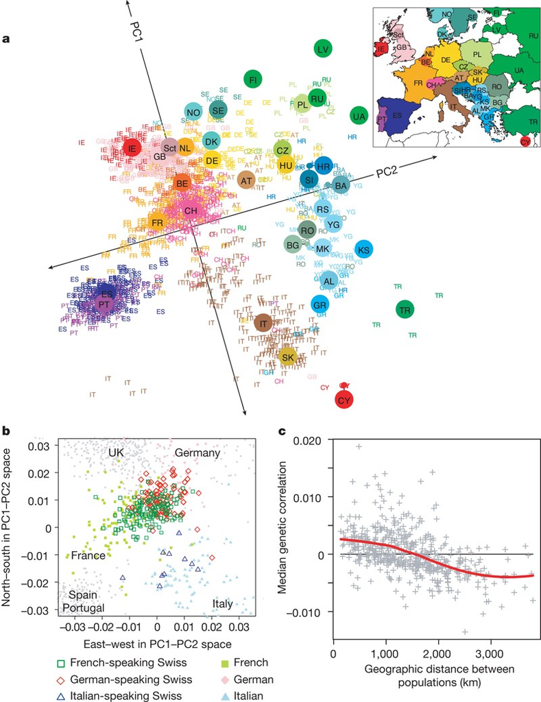

Above picture is from the article [Genes mirror geography within Europe](http://www.nature.com/nature/journal/v456/n7218/full/nature07331.html) by Novembre et al (2008) published in *Nature*.

- Use PCs to adjust for confounding - a serious issue in association studies in large data sets.
  - Use of PCA to adjust for confounding in modern genetic studies is proposed in the paper [Principal components analysis corrects for stratification in genome-wide association studies](http://www.nature.com/ng/journal/v38/n8/full/ng1847.html) by Price et al (2006) published in *Nature Genetics*. It has been cited 6,937 times as of May 3, 2019.

### 1.3.2 Low rank approximation

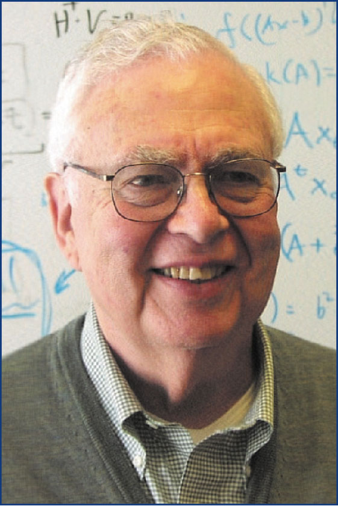

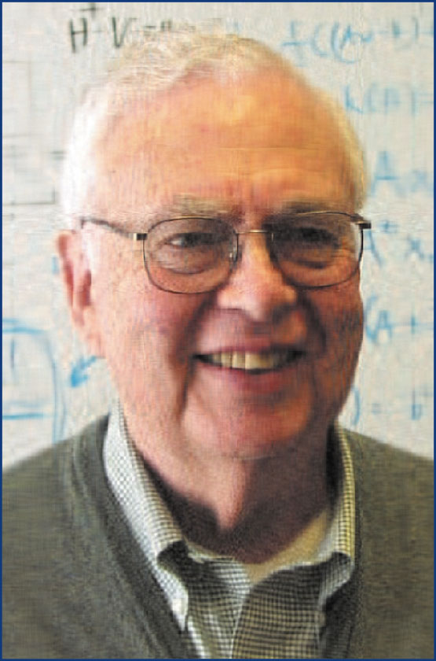

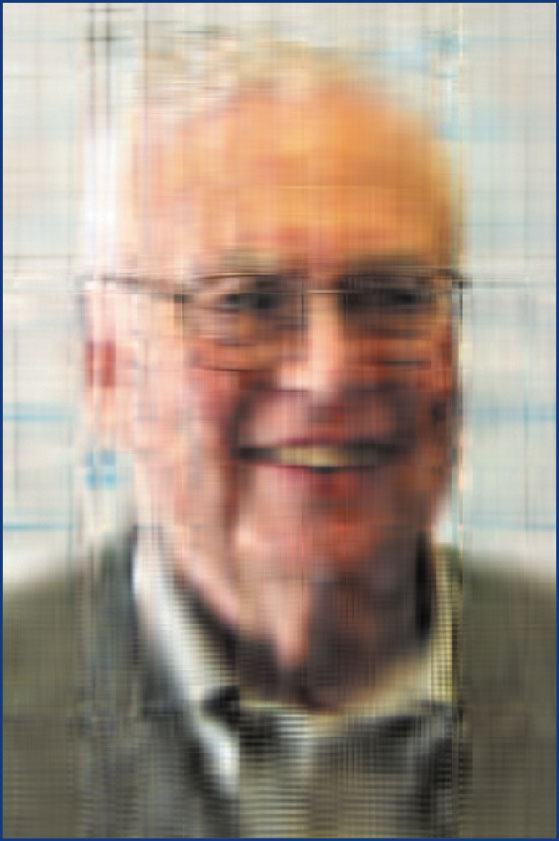

### 1.3.3 Moore-Penrose (MP) inverse

Using thin SVD,
$$\mathbf{A}^+ = \mathbf{V} \Sigma^+ \mathbf{U}^T,$$
where $\Sigma^+ = \text{diag}(\sigma_1^{-1}, \ldots, \sigma_r^{-1}, 0, \ldots, 0)$, $r= \text{rank}(\mathbf{A})$. This is how the [`pinv`](https://docs.julialang.org/en/v1/stdlib/LinearAlgebra/#LinearAlgebra.pinv) function is implemented in Julia.

```julia
using Random, LinearAlgebra

Random.seed!(123)
X = randn(5, 3)
pinv(X)
```

```
3×5 Matrix{Float64}:
  0.55218   -0.646969   0.0290464   0.256063  -0.116156
 -0.185495   0.321492  -0.0859872  -0.655442   0.495053
  0.479661  -0.14741    0.851572   -0.49494    0.630008
```

```julia
# calculation of Moore-Penrose inverse by SVD
@which pinv(X)
```

pinv(A::**AbstractMatrix{T}**; *atol, rtol*) *where T* in LinearAlgebra at /Applications/Julia-1.9.app/Contents/Resources/julia/share/julia/stdlib/v1.9/LinearAlgebra/src/dense.jl:1469

### 1.3.4 Least squares

Given thin SVD $\mathbf{X} = \mathbf{U} \Sigma \mathbf{V}^T$,
$$\begin{eqnarray*}
\widehat \beta &=& (\mathbf{X}^T \mathbf{X})^- \mathbf{X}^T \mathbf{y} \\
&=& (\mathbf{V} \Sigma^2 \mathbf{V}^T)^+ \mathbf{V} \Sigma \mathbf{U}^T \mathbf{y} \\
&=& \mathbf{V} (\Sigma^{2})^+ \mathbf{V}^T \mathbf{V} \Sigma \mathbf{U}^T \mathbf{y} \\
&=& \mathbf{V}_r \Sigma_r^{-1} \mathbf{U}_r^T \mathbf{y} \\
&=& \sum_{i=1}^r \left( \frac{\mathbf{u}_i^T \mathbf{y}}{\sigma_i} \right) \mathbf{v}_i
\end{eqnarray*}$$
and
$$\begin{eqnarray*}
\widehat{\mathbf{y}} &=& \mathbf{X} \widehat \beta = \mathbf{U}_r \mathbf{U}_r^T \mathbf{y}.
\end{eqnarray*}$$
In general, SVD is more expensive than other approaches (Cholesky, Sweep, QR) we learnt. In some applications, SVD is computed for other purposes then we get least squares solution for free.

### 1.3.5 Ridge regression

- In ridge regression, we minimize
  $$\|\mathbf{y} - \mathbf{X} \beta\|_2^2 + \lambda \|\beta\|_2^2,$$
  where $\lambda$ is a tuning parameter.
- Ridge regression by augmented linear regression. Ridge regression problem is equivalent to
  $$\left\| \begin{pmatrix} \mathbf{y} \\ \mathbf{0}_p \end{pmatrix} - \begin{pmatrix}
  \mathbf{X} \\ \sqrt \lambda \mathbf{I}_p
  \end{pmatrix} \beta \right\|_2^2.$$
  Therefore any methods for linear regression can be applied.
- Ridge regression by method of normal equation. The normal equation for the ridge problem is
  $$(\mathbf{X}^T \mathbf{X} + \lambda \mathbf{I}_p) \beta = \mathbf{X}^T \mathbf{y}.$$
  Therefore Cholesky or sweep operator can be used.
- Ridge regression by SVD. If we obtain the (thin) SVD of $\mathbf{X}$
  $$\mathbf{X} = \mathbf{U} \Sigma_{p \times p} \mathbf{V}^T.$$
  Then the normal equation reads
  $$(\Sigma^2 + \lambda \mathbf{I}_p) \mathbf{V}^T \beta = \Sigma \mathbf{U}^T \mathbf{y}$$
  and we get
  $$\widehat \beta (\lambda) = \sum_{i=1}^p \frac{\sigma_i \mathbf{u}_i^T \mathbf{y}}{\sigma_i^2 + \lambda} \mathbf{v}_i = \sum_{i=1}^r \frac{\sigma_i \mathbf{u}_i^T \mathbf{y}}{\sigma_i^2 + \lambda} \mathbf{v}_i, \quad r = \text{rank}(\mathbf{X}).$$
  It is clear that
  $$\begin{eqnarray*}
  \lim_{\lambda \to 0} \widehat \beta (\lambda) = \widehat \beta_{\text{OLS}}
  \end{eqnarray*}$$
  and $\|\widehat \beta (\lambda)\|_2$ is monotone decreasing as $\lambda$ increases.
- Only one SVD is needed for all $\lambda$ (!), in contrast to the method of augmented linear regression, Cholesky, or sweep.

### 1.3.6 Other applications

See Chapters 8-9 of [Numerical Analysis for Statisticians](http://ucla.worldcat.org/title/numerical-analysis-for-statisticians/oclc/793808354&referer=brief_results) by Kenneth Lange (2010) for more applications of eigen-decomposition and SVD.

## 1.4 Algorithms for eigen-decomposition

### 1.4.1 One eigen-pair: power method

- **Power method** iterates according to
  $$\begin{eqnarray*}
  \mathbf{x}^{(t)} &\gets& \frac{1}{\|\mathbf{A} \mathbf{x}^{(t-1)}\|_2} \mathbf{A} \mathbf{x}^{(t-1)}
  \end{eqnarray*}$$
  from an initial guess $\mathbf{x}^{(0)}$ of unit norm.
- Suppose we arrange $|\lambda_1| > |\lambda_2| \ge \cdots \ge |\lambda_n|$ (the first inequality strict) with corresponding eigenvectors $\mathbf{u}_i$, and expand $\mathbf{x}^{(0)} = c_1 \mathbf{u}_1 + \cdots + c_n \mathbf{u}_n$, then
  $$\begin{eqnarray*}
  \mathbf{x}^{(t)} &=& \frac{\left( \sum_i \lambda_i^t \mathbf{u}_i \mathbf{u}_i^T \right) \left( \sum_i c_i \mathbf{u}_i \right)}{\|\left( \sum_i \lambda_i^t \mathbf{u}_i \mathbf{u}_i^T \right) \left( \sum_i c_i \mathbf{u}_i \right)\|_2} \\
  &=& \frac{\sum_i c_i \lambda_i^t \mathbf{u}_i}{\|\sum_i c_i \lambda_i^t \mathbf{u}_i\|_2} \\
  &=& \frac{c_1 \mathbf{u}_1 + c_2 (\lambda_2/\lambda_1)^t \mathbf{u}_2 + \cdots + c_n (\lambda_n/\lambda_1)^t \mathbf{u}_n}{\|c_1 \mathbf{u}_1 + c_2 (\lambda_2/\lambda_1)^t \mathbf{u}_2 + \cdots + c_n (\lambda_n/\lambda_1)^t \mathbf{u}_n\|_2} \left( \frac{\lambda_1}{|\lambda_1|} \right)^t.
  \end{eqnarray*}$$
  Thus $\mathbf{x}^{(t)} - \frac{c_1 \mathbf{u}_1}{\|c_1 \mathbf{u}_1\|_2} \left( \frac{\lambda_1}{|\lambda_1|} \right)^t \to 0$ as $t \to \infty$. The convergence rate is $|\lambda_2|/|\lambda_1|$.
- $\lambda_1^{(t)} = \mathbf{x}^{(t)T} \mathbf{A} \mathbf{x}^{(t)}$ converges to $\lambda_1$.
- **Inverse power method** for finding the eigenvalue of smallest absolute value: Substitute $\mathbf{A}$ by $\mathbf{A}^{-1}$ in the power method. (E.g., pre-compute LU or Cholesky of $\mathbf{A}$).
- **Shifted inverse power**: Substitute $(\mathbf{A} - \mu \mathbf{I})^{-1}$ in the power method. It converges to an eigenvalue close to the given $\mu$.
- **Rayleigh quotient iteration**: Substitute $(\mathbf{A} - \mu^{(t-1)} \mathbf{I})^{-1}$, where $\mu^{(t-1)} = \mathbf{x}^{(t-1)T} \mathbf{A} \mathbf{x}^{(t-1)}$ in the shifted inverse method. Faster convergence.
- Example: PageRank problem seeks top left eigenvector of transition matrix $\mathbf{P}$ and costs $O(n)$ per iteration.

### 1.4.2 Top $r$ eigen-pairs: orthogonal iteration

Generalization of power method to higher dimensional invariant subspace.

- **Orthogonal iteration**: Initialize $\mathbf{Q}^{(0)} \in \mathbb{R}^{n \times r}$ with orthonormal columns. For $t=1,2,\ldots$,
  $$\begin{eqnarray*}
  \mathbf{Z}^{(t)} &\gets& \mathbf{A} \mathbf{Q}^{(t-1)} \quad \text{($2n^2r$ flops)} \\
  \mathbf{Q}^{(t)} \mathbf{R}^{(t)} &\gets& \mathbf{Z}^{(t)} \quad \text{(QR factorization)}%, $nr^2 - r^3/3$ flops)}
  \end{eqnarray*}$$
- $\mathbf{Z}^{(t)}$ converges to the eigenspace of the largest $r$ eigenvalues if they are real and separated from remaining spectrum. The convergence rate is $|\lambda_{r+1}|/|\lambda_r|$.

### 1.4.3 (Impractical) full eigen-decomposition: QR iteration

Assume $\mathbf{A} \in \mathbb{R}^{n \times n}$ symmetric.

- Take $r=n$ in the orthogonal iteration. Then $\mathbf{Q}^{(t)}$ converges to the eigenspace $\mathbf{U}$ of $\mathbf{A}$. This implies that
  $$\mathbf{T}^{(t)} := \mathbf{Q}^{(t)T} \mathbf{A} \mathbf{Q}^{(t)}$$
  converges to a diagonal form $\Lambda = \text{diag}(\lambda_1, \ldots, \lambda_n)$.
- Note how to compute $\mathbf{T}^{(t)}$ from $\mathbf{T}^{(t-1)}$
  $$\begin{eqnarray*}
  \mathbf{T}^{(t-1)} &=& \mathbf{Q}^{(t-1)T} \mathbf{A} \mathbf{Q}^{(t-1)} = \mathbf{Q}^{(t-1)T} (\mathbf{A} \mathbf{Q}^{(t-1)}) = (\mathbf{Q}^{(t-1)T} \mathbf{Q}^{(t)}) \mathbf{R}^{(t)} \\\mathbf{A}
  \mathbf{T}^{(t)} &=& \mathbf{Q}^{(t)T} \mathbf{A} \mathbf{Q}^{(t)} = \mathbf{Q}^{(t)T} \mathbf{A} \mathbf{Q}^{(t-1)} \mathbf{Q}^{(t-1)T} \mathbf{Q}^{(t)} = \mathbf{R}^{(t)} ( \mathbf{Q}^{(t-1)T} \mathbf{Q}^{(t)}).
  \end{eqnarray*}$$
- **QR iteration**: Initialize $\mathbf{U}^{(0)} \in \mathbb{R}^{n \times n}$ orthogonal and set $\mathbf{T}^{(0)} = \mathbf{U}^{(0)T} \mathbf{A} \mathbf{U}^{(0)}$. \ For $t=1,2,\ldots$
  $$\begin{eqnarray*}
  \mathbf{U}^{(t)} \mathbf{R}^{(t)} &\gets& \mathbf{T}^{(t-1)} \quad \text{(QR factorization)} \\
  \mathbf{T}^{(t)} &\gets& \mathbf{R}^{(t)} \mathbf{U}^{(t)}
  \end{eqnarray*}$$
- QR iteration is expensive in general: $O(n^3)$ per iteration and linear convergence rate.

### 1.4.4 QR algorithm for symmetric eigen-decomposition

Assume $\mathbf{A} \in \mathbb{R}^{n \times n}$ symmetric.

- Reading: [The QR algorithm](http://hua-zhou.github.io/teaching/biostatm280-2018spring/readings/qr.pdf) by Beresford N. Parlett.
- This is the algorithm implemented in LAPACK: used by Julia, Matlab, R.

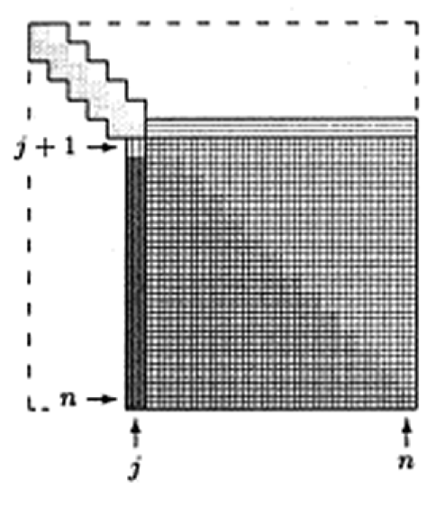

- Idea: Tri-diagonalization (by Householder) + QR iteration on the tri-diagonal system with implicit shift.
  0. Step 1: Householder tri-diagonalization: $4n^3/3$ for eigenvalues only, $8n^3/3$ for both eigenvalues and eigenvectors. (Why can’t we apply Householder to make it diagonal directly?)
  1. Step 2: QR iteration on the tridiagonal matrix. Implicit shift accelerates convergence rate. On average 1.3-1.6 QR iteration per eigenvalue, $\sim 20n$ flops per QR iteration. So total operation count is about $30n^2$. Eigenvectors need an extra of about $6n^3$ flops.

[output not shown]

- Message: **Don’t request eigenvectors unless necessary**. Use [`eigvals`](https://docs.julialang.org/en/v1/stdlib/LinearAlgebra/#LinearAlgebra.eigvals) in Julia to request only eigenvalues.
- The **unsymmetric QR algorithm** obtains the real Schur decomposition of an asymmetric matrix $\mathbf{A}$.

### 1.4.5 Example

Julia functions: [`eigen`](https://docs.julialang.org/en/v1/stdlib/LinearAlgebra/#LinearAlgebra.eigen), [`eigen!`](https://docs.julialang.org/en/v1/stdlib/LinearAlgebra/#LinearAlgebra.eigen!), [`eigvals`](https://docs.julialang.org/en/v1/stdlib/LinearAlgebra/#LinearAlgebra.eigvals!), [`eigvecs`](https://docs.julialang.org/en/v1/stdlib/LinearAlgebra/#LinearAlgebra.eigvecs), [`eigmax`](https://docs.julialang.org/en/v1/stdlib/LinearAlgebra/#LinearAlgebra.eigmax), [`eigmin`](https://docs.julialang.org/en/v1/stdlib/LinearAlgebra/#LinearAlgebra.eigmin).

```julia
Random.seed!(123)
A = Symmetric(randn(5, 5), :U)
Aeig = eigen(A)
```

```
Eigen{Float64, Float64, Matrix{Float64}, Vector{Float64}}
values:
5-element Vector{Float64}:
 -3.852502725326395
 -0.9957775596103877
 -0.446848243300765
  1.3655958826562995
  2.8778151937868666
vectors:
5×5 Matrix{Float64}:
 -0.445328     0.0380181   0.299237    0.534168  -0.652195
 -0.00876336   0.891758   -0.111185   -0.342663  -0.273699
  0.156911    -0.148357   -0.884934    0.189716  -0.366427
 -0.529748    -0.370278   -0.0707939  -0.70901   -0.273048
  0.704523    -0.210255    0.331625   -0.24199   -0.539357
```

```julia
# eigen-values
Aeig.values
```

```
5-element Vector{Float64}:
 -3.852502725326395
 -0.9957775596103877
 -0.446848243300765
  1.3655958826562995
  2.8778151937868666
```

```julia
# eigen-vectors
Aeig.vectors
```

```
5×5 Matrix{Float64}:
 -0.445328     0.0380181   0.299237    0.534168  -0.652195
 -0.00876336   0.891758   -0.111185   -0.342663  -0.273699
  0.156911    -0.148357   -0.884934    0.189716  -0.366427
 -0.529748    -0.370278   -0.0707939  -0.70901   -0.273048
  0.704523    -0.210255    0.331625   -0.24199   -0.539357
```

```julia
# inversion by eigen-decomposition
inv(Aeig)
```

```
5×5 Matrix{Float64}:
  0.103435   -0.0326116   0.773661   -0.215148  -0.105034
 -0.0326116  -0.714276   -0.0997287   0.516655   0.384428
  0.773661   -0.0997287  -1.708      -0.237522   0.631784
 -0.215148    0.516655   -0.237522    0.172274   0.248048
 -0.105034    0.384428    0.631784    0.248048  -0.275379
```

```julia
@which inv(Aeig)
```

inv(A::**Eigen**) in LinearAlgebra at /Applications/Julia-1.9.app/Contents/Resources/julia/share/julia/stdlib/v1.9/LinearAlgebra/src/eigen.jl:436

```julia
# determinant by eigen-decomposition
det(Aeig)
```

```
-6.736750207215879
```

```julia
@which det(Aeig)
```

det(A::**Eigen**) in LinearAlgebra at /Applications/Julia-1.9.app/Contents/Resources/julia/share/julia/stdlib/v1.9/LinearAlgebra/src/eigen.jl:437

```julia
@which eigvals(A)
```

eigvals(A::**Union{Hermitian{T, S}, Hermitian{Complex{T}, S}, Symmetric{T, S}} where {T<:Real, S}**; *sortby*) in LinearAlgebra at /Applications/Julia-1.9.app/Contents/Resources/julia/share/julia/stdlib/v1.9/LinearAlgebra/src/symmetriceigen.jl:72

```julia
@which eigmax(A)
```

eigmax(A::**Union{Hermitian{var"#s970", S}, Hermitian{Complex{var"#s970"}, S}, Symmetric{var"#s970", S}} where {var"#s970"<:Real, S}**) in LinearAlgebra at /Applications/Julia-1.9.app/Contents/Resources/julia/share/julia/stdlib/v1.9/LinearAlgebra/src/symmetriceigen.jl:156

```julia
@which eigmin(A)
```

eigmin(A::**Union{Hermitian{var"#s970", S}, Hermitian{Complex{var"#s970"}, S}, Symmetric{var"#s970", S}} where {var"#s970"<:Real, S}**) in LinearAlgebra at /Applications/Julia-1.9.app/Contents/Resources/julia/share/julia/stdlib/v1.9/LinearAlgebra/src/symmetriceigen.jl:157

Don’t request eigenvectors unless needed.

```julia
using BenchmarkTools, Random, LinearAlgebra

Random.seed!(123)
n = 1000
A = Symmetric(randn(n, n), :U)
```

```
1000×1000 Symmetric{Float64, Matrix{Float64}}:
  0.808288     1.29539    -1.45707    -0.679367    …   1.16225      1.70184
  1.29539     -0.0401347   0.558171   -0.1036          0.938894    -0.393461
 -1.45707      0.558171   -1.86708     1.79034         1.40001      0.773572
 -0.679367    -0.1036      1.79034    -1.17117        -0.00718212  -1.39607
  0.319691     0.48319     0.749465    0.877189       -0.0813753   -0.12452
 -0.558467    -0.0516554   1.39446    -1.22875     …  -0.463411     0.891155
  1.29691      0.13272    -1.09308    -0.777442       -2.29691     -1.94448
  0.221109     0.901772   -1.83674    -1.53517         0.71271     -1.09901
 -0.131222    -1.95005    -0.871313    0.749873       -0.512097     0.147288
  1.06375     -0.507892    0.0770292  -1.07807        -0.388376    -0.296149
  0.0488582   -1.70595     1.4607      0.898609    …   0.258443    -0.124589
 -0.964277     1.65598    -0.609166   -0.372021        0.167224     1.22886
 -1.57168      0.367311   -0.718299   -1.08922         0.994994     1.21551
  ⋮                                                ⋱
 -0.0398698    1.19093     1.93918    -0.481359       -0.688618     0.7274
  0.171639     1.04954    -1.45874    -1.13007        -0.338185     1.21151
 -0.617088     1.28266     3.04803    -0.782317    …   1.44645     -1.33859
  0.00011278   0.0951171   0.641481    1.11716        -0.826472     1.51133
  0.468151    -0.106804   -0.669451   -1.10934        -0.439259     0.641367
 -0.695767    -0.576123   -0.295149    0.525354        0.973504    -0.0769707
  0.194844     0.582761   -0.144439    0.133758       -0.963        0.22916
 -1.34654      0.311999    0.389583    0.393329    …  -0.300726     1.58836
 -0.140269     1.52204    -0.2398     -1.13262         0.0982528    0.700468
  0.00795371   0.129432    0.471772    0.00684241      0.998041     0.836767
  1.16225      0.938894    1.40001    -0.00718212     -0.933037    -0.710069
  1.70184     -0.393461    0.773572   -1.39607        -0.710069     0.0106993
```

```julia
# requesting eigenvalues only is cheaper
@benchmark eigvals($A)
```

```
BenchmarkTools.Trial: 118 samples with 1 evaluation.
 Range (min … max):  37.855 ms … 53.368 ms  ┊ GC (min … max): 0.00% … 0.00%
 Time  (median):     42.067 ms              ┊ GC (median):    0.00%
 Time  (mean ± σ):   42.560 ms ±  2.906 ms  ┊ GC (mean ± σ):  0.80% ± 1.83%
       ▂ ▂ █▄  █▄▂▄ ▂ ▂▆▆  ▂
  ▄▁▆█▄███▆███████████████▆███▄▄▄▁▆▁▆▁▄▄▆▁▄▄▁▁▁▁▁▄▄▁▁▁▁▄▁▁▁▁▄ ▄
  37.9 ms         Histogram: frequency by time        52.4 ms <
 Memory estimate: 7.99 MiB, allocs estimate: 11.
```

```julia
# requesting eigenvectors requires extra work
@benchmark eigen($A)
```

```
BenchmarkTools.Trial: 38 samples with 1 evaluation.
 Range (min … max):  126.256 ms … 168.283 ms  ┊ GC (min … max): 0.00% … 1.30%
 Time  (median):     132.232 ms               ┊ GC (median):    0.34%
 Time  (mean ± σ):   134.232 ms ±   8.475 ms  ┊ GC (mean ± σ):  0.68% ± 0.75%
  █ ▁ ▄▁█▁▁▄█▄
  █▁█▆████████▆▁▁▆▁▁▁▁▁▁▁▁▁▆▆▁▆▁▁▁▁▁▁▆▁▁▆▁▁▁▁▁▁▁▁▁▁▁▁▁▁▁▁▁▁▁▁▁▆ ▁
  126 ms           Histogram: frequency by time          168 ms <
 Memory estimate: 23.25 MiB, allocs estimate: 13.
```

```julia
@benchmark eigvecs($A)
```

```
BenchmarkTools.Trial: 38 samples with 1 evaluation.
 Range (min … max):  128.798 ms … 144.298 ms  ┊ GC (min … max): 0.00% … 0.00%
 Time  (median):     134.912 ms               ┊ GC (median):    0.22%
 Time  (mean ± σ):   134.810 ms ±   3.469 ms  ┊ GC (mean ± σ):  0.78% ± 0.86%
      █        ▃▃▃  ▃        ▃█  █▃
  ▇▁▁▇█▁▁▁▁▇▇▁▁███▇▁█▁▁▇▇▇▇▁▇██▇▁██▇▁▁▁▁▁▇▁▁▁▇▁▇▁▁▁▁▁▇▁▁▁▁▁▁▁▁▇ ▁
  129 ms           Histogram: frequency by time          144 ms <
 Memory estimate: 23.25 MiB, allocs estimate: 13.
```

## 1.5 Algorithm for singular value decomposition (SVD)

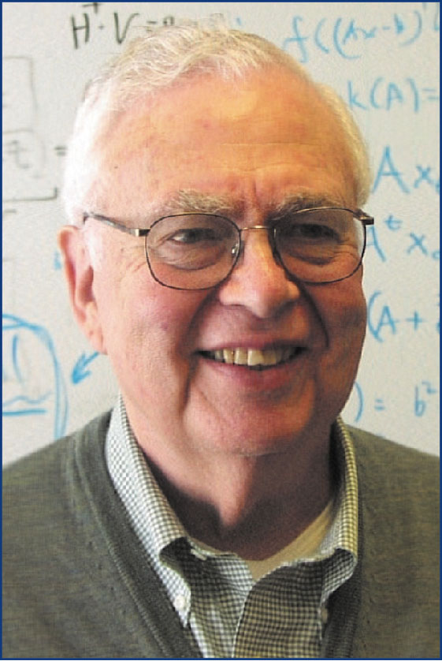

[figure not shown]

Assume $\mathbf{A} \in \mathbb{R}^{m \times n}$ and we seek the SVD $\mathbf{A} = \mathbf{U} \mathbf{D} \mathbf{V}^T$.

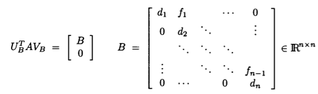

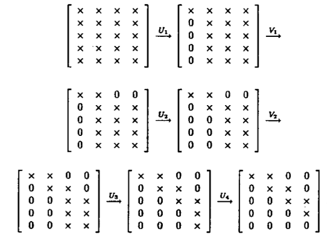

- **Golub-Kahan-Reinsch algorithm**:
  - Stage 1: Transform $\mathbf{A}$ to an upper bidiagonal form $\mathbf{B}$ (by Householder).
  - Stage 2: Apply implicit-shift QR iteration to the tridiagonal matrix $\mathbf{B}^T \mathbf{B}$ *implicitly*.
- See Section 8.6 of [Matrix Computation](http://catalog.library.ucla.edu/vwebv/holdingsInfo?bibId=7122088) by Gene Golub and Charles Van Loan (2013) for more details.
- $4m^2 n + 8mn^2 + 9n^3$ flops for a tall $(m \ge n)$ matrix.

### 1.5.1 Example

Julia functions: [`svd`](https://docs.julialang.org/en/v1/stdlib/LinearAlgebra/#LinearAlgebra.svd), [`svd!`](https://docs.julialang.org/en/v1/stdlib/LinearAlgebra/#LinearAlgebra.svd), [`svdvals`](https://docs.julialang.org/en/v1/stdlib/LinearAlgebra/#LinearAlgebra.svdvals), [`svdvals!`](https://docs.julialang.org/en/v1/stdlib/LinearAlgebra/#LinearAlgebra.svdvals!).

```julia
Random.seed!(123)

A = randn(5, 3)
Asvd = svd(A)
```

```
SVD{Float64, Float64, Matrix{Float64}, Vector{Float64}}
U factor:
5×3 Matrix{Float64}:
 -0.246849  -0.595292  -0.23902
  0.407797   0.633393  -0.0315365
  0.746221  -0.302242  -0.544096
  0.397364  -0.36151    0.551056
 -0.240882   0.149667  -0.584954
singular values:
3-element Vector{Float64}:
 2.626881694369156
 0.8802559276491181
 0.7439968442670012
Vt factor:
3×3 Matrix{Float64}:
 -0.65339    -0.701302   0.285057
 -0.754579    0.573122  -0.319595
  0.0607604  -0.423918  -0.90366
```

```julia
Asvd.U
```

```
5×3 Matrix{Float64}:
 -0.246849  -0.595292  -0.23902
  0.407797   0.633393  -0.0315365
  0.746221  -0.302242  -0.544096
  0.397364  -0.36151    0.551056
 -0.240882   0.149667  -0.584954
```

```julia
# Vt is cheaper to extract than V
Asvd.Vt
```

```
3×3 Matrix{Float64}:
 -0.65339    -0.701302   0.285057
 -0.754579    0.573122  -0.319595
  0.0607604  -0.423918  -0.90366
```

```julia
Asvd.V
```

```
3×3 adjoint(::Matrix{Float64}) with eltype Float64:
 -0.65339   -0.754579   0.0607604
 -0.701302   0.573122  -0.423918
  0.285057  -0.319595  -0.90366
```

```julia
Asvd.S
```

```
3-element Vector{Float64}:
 2.626881694369156
 0.8802559276491181
 0.7439968442670012
```

**Don’t request singular vectors unless needed.**

```julia
Random.seed!(123)

n, p = 1000, 500
A = randn(n, p)
@benchmark svdvals(A)
```

```
BenchmarkTools.Trial: 134 samples with 1 evaluation.
 Range (min … max):  33.891 ms … 44.077 ms  ┊ GC (min … max): 0.00% … 8.95%
 Time  (median):     37.404 ms              ┊ GC (median):    0.00%
 Time  (mean ± σ):   37.482 ms ±  1.671 ms  ┊ GC (mean ± σ):  0.70% ± 2.20%
            ▂       █▃█▂▅ ▅▅
  ▅▃▃▅▅▃▁▃▅▁█▃▃█▁▆▃▇█████▇███▇▇█▃▃▃▁▃▃▅▃▃▅▁▁▃▁▃▁▁▁▁▃▁▃▁▁▁▁▁▁▃ ▃
  33.9 ms         Histogram: frequency by time        43.4 ms <
 Memory estimate: 4.11 MiB, allocs estimate: 9.
```

```julia
@benchmark svd(A)
```

```
BenchmarkTools.Trial: 83 samples with 1 evaluation.
 Range (min … max):  55.027 ms … 67.249 ms  ┊ GC (min … max): 0.00% … 4.11%
 Time  (median):     60.447 ms              ┊ GC (median):    0.00%
 Time  (mean ± σ):   60.422 ms ±  2.342 ms  ┊ GC (mean ± σ):  1.21% ± 1.74%
                       ▂    ▂  █   ▂▂  ▂   ▂▅  ▂        ▅
  ▅▁▁▅▁▅▅▁▁▁▅▁▅█▅█▅▁█▅▅██▅▅███▅███▅█████▅▅███▅▁██▁▁▁▅█▁▅█▅▁▅▅ ▁
  55 ms           Histogram: frequency by time        64.7 ms <
 Memory estimate: 17.23 MiB, allocs estimate: 12.
```

## 1.6 Lanczos/Arnoldi iterative method for top eigen-pairs

- Consider the Google PageRank problem. We want to find the top left eigenvector of the transition matrix $\mathbf{P}$. Direct methods such as (unsymmetric) QR or SVD takes forever. Iterative methods such as power method is feasible. However power method may take a large number of iterations.
- **Krylov subspace methods** are the state-of-art iterative methods for obtaining the top eigen-values/vectors or singular values/vectors of large **sparse** or **structured** matrices.
- **Lanczos method**: top eigen-pairs of a large *symmetric* matrix.
- **Arnoldi method**: top eigen-pairs of a large *asymmetric* matrix.
- Both methods are also adapted to obtain top singular values/vectors of large sparse or structured matrices.
- `eigs` and `svds` in Julia Arpack.jl package and Matlab are wrappers of the ARPACK package, which implements Lanczos and Arnoldi methods.

```julia
using MatrixDepot, SparseArrays

# Download the Boeing/bcsstk38 matrix (sparse, pd, 8032-by-8032) from SuiteSparse collection
# https://www.cise.ufl.edu/research/sparse/matrices/Boeing/bcsstk38.html
A = matrixdepot("Boeing/bcsstk38")
# Change type of A from Symmetric{Float64,SparseMatrixCSC{Float64,Int64}} to SparseMatrixCSC
A = sparse(A)
@show typeof(A)
Afull = Matrix(A)
@show typeof(Afull)
# actual sparsity level
count(!iszero, A) / length(A)
```

```
[ Info: verify download of index files...
[ Info: reading database
[ Info: adding metadata...
[ Info: adding svd data...
[ Info: writing database
[ Info: used remote sites are sparse.tamu.edu with MAT index and math.nist.gov with HTML index
```

```
typeof(A) = SparseMatrixCSC{Float64, Int64}
typeof(Afull) = Matrix{Float64}
```

```
0.005509895180235235
```

```julia
using UnicodePlots
spy(A)
```

```
         ┌──────────────────────────────────────────┐
       1 │⢿⣷⣆⠀⠀⠀⠀⠀⠀⠀⠀⠀⠀⠀⠀⠀⠀⠀⠀⠀⠀⠀⠀⠀⠀⠀⠀⠀⠀⠀⠀⠀⠀⠀⠀⠀⠀⠀⠀⠀⠀⠀│ > 0
         │⠈⠙⢻⣶⣄⠀⠀⠀⠀⠀⡀⠀⠀⠀⠀⠀⠀⠀⠀⠀⠀⠀⠀⠀⠀⠀⠀⠀⠀⠀⠀⠀⠀⠀⠀⠀⠀⠀⠀⠀⠀⠀│ < 0
         │⠀⠀⠀⠙⢻⣶⡳⣒⠀⠉⣛⠀⠀⠀⠀⠀⠀⠀⠀⠀⠀⠀⠀⠀⠀⠀⠀⠀⠀⠀⠀⠀⠀⠀⠀⠀⠀⠀⠀⠀⠀⠀│
         │⠀⠀⠀⠀⢹⢪⡿⣯⣤⣤⢩⢀⠀⠀⠀⠀⠀⠀⠀⠀⠀⠀⠀⠀⠀⠀⠀⠀⠀⠀⠀⠀⠀⠀⠀⠀⠀⠀⠀⠀⠀⠀│
         │⠀⠀⠀⠀⡄⠀⠀⣿⣿⣿⣿⣬⠀⠠⡄⠀⠀⠀⠀⠀⠀⠀⠀⠀⠀⠀⠀⠀⠀⠀⠀⠀⠀⠀⠀⠀⠀⠀⠀⠀⠀⡀│
         │⠀⠀⠀⠈⠛⠘⠃⢒⡛⣿⣿⣿⣀⢴⣆⠀⠀⠀⠀⠀⠀⠀⠀⠀⠀⠀⠀⠀⠀⠀⠀⠀⠀⠀⠀⠀⠀⠀⠀⠀⠀⣠│
         │⠀⠀⠀⠀⠀⠀⠀⠀⠀⡀⢀⣜⡿⣯⣿⠇⠼⠤⠀⠀⠀⠀⠀⠀⠀⠀⠀⠀⠀⠀⠀⠀⠀⠀⠀⠀⠀⠀⠀⠀⠀⢛│
         │⠀⠀⠀⠀⠀⠀⠀⠀⠀⠉⠈⠙⠿⠟⢻⣶⣤⡄⠀⠀⠀⠀⠀⠀⠀⠀⠀⠀⠀⠀⠀⠀⠀⠀⠀⠀⠀⠀⠀⠀⠀⠳│
         │⠀⠀⠀⠀⠀⠀⠀⠀⠀⠀⠀⠀⠒⡇⠀⠿⣿⣿⣾⢰⠀⢠⠀⠀⠀⠀⠀⠀⠠⠀⠀⠀⠀⠀⠀⠀⠀⠀⠀⠀⠀⠀│
         │⠀⠀⠀⠀⠀⠀⠀⠀⠀⠀⠀⠀⠀⠀⠀⠀⢚⣛⣿⣿⣶⣔⠀⠀⠀⠀⠀⠀⠀⠀⠀⠀⠀⠀⠀⠀⠀⠀⠀⠀⠀⠀│
         │⠀⠀⠀⠀⠀⠀⠀⠀⠀⠀⠀⠀⠀⠀⠀⠀⠀⣀⢘⢿⣿⣿⡿⡇⠿⡶⠀⠀⠀⠀⠀⠀⠀⠀⠀⠀⠀⠀⠀⠀⠀⠀│
         │⠀⠀⠀⠀⠀⠀⠀⠀⠀⠀⠀⠀⠀⠀⠀⠀⠀⠀⠀⠀⠿⠯⡿⣯⡽⡗⠀⠀⠀⠀⠀⠀⠀⠀⠀⠀⠀⢠⡀⠀⠀⠀│
         │⠀⠀⠀⠀⠀⠀⠀⠀⠀⠀⠀⠀⠀⠀⠀⠀⠀⠀⠀⠀⢻⡧⢷⠯⢿⣷⣀⠀⢀⡀⠀⠀⠀⠀⠀⠀⠀⠈⠁⠀⠀⠀│
         │⠀⠀⠀⠀⠀⠀⠀⠀⠀⠀⠀⠀⠀⠀⠀⠀⠀⠀⠀⠀⠀⠀⠀⠀⠀⠘⠻⣦⣸⡇⣆⠀⠀⠀⠀⠀⠀⠀⠀⠀⠀⠀│
         │⠀⠀⠀⠀⠀⠀⠀⠀⠀⠀⠀⠀⠀⠀⠀⠀⠀⠂⠀⠀⠀⠀⠀⠀⠀⠰⠶⠾⢿⣷⣿⣄⠀⠀⠀⠀⠀⠀⠃⠐⠀⠀│
         │⠀⠀⠀⠀⠀⠀⠀⠀⠀⠀⠀⠀⠀⠀⠀⠀⠀⠀⠀⠀⠀⠀⠀⠀⠀⠀⠈⠙⠛⢿⣿⣿⡷⡆⠀⠀⢘⡒⠲⡖⠀⡆│
         │⠀⠀⠀⠀⠀⠀⠀⠀⠀⠀⠀⠀⠀⠀⠀⠀⠀⠀⠀⠀⠀⠀⠀⠀⠀⠀⠀⠀⠀⠀⠹⠯⢻⣶⣾⣣⠀⠄⠑⠄⠆⠆│
         │⠀⠀⠀⠀⠀⠀⠀⠀⠀⠀⠀⠀⠀⠀⠀⠀⠀⠀⠀⠀⠀⠀⠀⠀⠀⠀⠀⠀⠀⠀⠀⠀⠾⣻⣿⣿⡃⡀⠒⠂⠂⠀│
         │⠀⠀⠀⠀⠀⠀⠀⠀⠀⠀⠀⠀⠀⠀⠀⠀⠀⠀⠀⠀⠀⠀⠀⣀⡀⠀⠀⠀⠀⠀⢲⠰⠀⠄⠉⠨⡿⣯⡙⢨⡃⠀│
         │⠀⠀⠀⠀⠀⠀⠀⠀⠀⠀⠀⠀⠀⠀⠀⠀⠀⠀⠀⠀⠀⠀⠀⠈⠁⠀⠀⠀⢉⠀⢸⠦⠑⠄⠸⠀⡓⣈⠿⣧⣮⡇│
   8 032 │⠀⠀⠀⠀⠀⠀⠀⠀⠀⠠⠀⣠⣤⢀⢤⡀⠀⠀⠀⠀⠀⠀⠀⠀⠀⠀⠀⠀⠀⠀⠠⠤⠨⠅⠈⠀⠉⠈⠮⠿⠿⣧│
         └──────────────────────────────────────────┘
         ⠀1⠀⠀⠀⠀⠀⠀⠀⠀⠀⠀⠀⠀⠀⠀⠀⠀⠀⠀⠀⠀⠀⠀⠀⠀⠀⠀⠀⠀⠀⠀⠀⠀⠀⠀⠀⠀8 032⠀
         ⠀⠀⠀⠀⠀⠀⠀⠀⠀⠀⠀⠀⠀⠀⠀⠀⠀355 460 ≠ 0⠀⠀⠀⠀⠀⠀⠀⠀⠀⠀⠀⠀⠀⠀⠀⠀
```

```julia
# top 5 eigenvalues by LAPACK (QR algorithm)
n = size(A, 1)
@time eigvals(Symmetric(Afull), (n-4):n)
```

```
 13.751147 seconds (6.71 k allocations: 495.466 MiB, 0.06% gc time, 0.04% compilation time)
```

```
5-element Vector{Float64}:
 1.006580894023709e9
 2.575326809321931e9
 2.5900252061972675e9
 3.9998475579818964e11
 4.042307487727891e11
```

```julia
using Arpack
# top 5 eigenvalues by iterative methods
@time eigs(A; nev=5, ritzvec=false, which=:LM)
```

```
  1.101833 seconds (3.85 M allocations: 260.300 MiB, 7.14% gc time, 98.57% compilation time)
```

```
([4.042307487727891e11, 3.9998475579818933e11, 2.5900252061972437e9, 2.575326809321966e9, 1.0065808940236921e9], 5, 3, 44, [-1.0868122619264564e6, 421656.3313667729, -89930.27953474737, 1.5161178968501016e6, -171347.63736619186, 529000.7873842014, -1.0162884032067e6, -162954.5459122519, -1.136964763…
```

```julia
@benchmark eigs($A; nev=5, ritzvec=false, which=:LM)
```

```
BenchmarkTools.Trial: 346 samples with 1 evaluation.
 Range (min … max):  13.189 ms … 23.653 ms  ┊ GC (min … max): 0.00% … 0.00%
 Time  (median):     13.850 ms              ┊ GC (median):    0.00%
 Time  (mean ± σ):   14.466 ms ±  1.475 ms  ┊ GC (mean ± σ):  0.61% ± 2.90%
    ▅▇███▆▅▄▃▃▂                         ▂  ▁
  ▇▆███████████▆▅█▅▁▆▆▆▁▅▁▇▁█▁▁▅▅▆▁▁▁▅▆▆██▆██▁▆█▁▆▆▅▇▅▅▆▁▁▅▁▅ ▇
  13.2 ms      Histogram: log(frequency) by time      18.9 ms <
 Memory estimate: 1.55 MiB, allocs estimate: 406.
```

We see >1000 fold speedup in this case.

## 1.7 Jacobi method for symmetric eigen-decomposition

Assume $\mathbf{A} \in \mathbf{R}^{n \times n}$ is symmetric and we seek the eigen-decomposition $\mathbf{A} = \mathbf{U} \Lambda \mathbf{U}^T$.

- Idea: Systematically reduce off-diagonal entries
  $$\text{off}(\mathbf{A}) = \sum_i \sum_{j \ne i} a_{ij}^2$$
  by Jacobi rotations.
- Jacobi/Givens rotations:
  $$\begin{eqnarray*}
  \mathbf{J}(p,q,\theta) = \begin{pmatrix}
  1 & & 0 & & 0 & & 0 \\
  \vdots & \ddots & \vdots & & \vdots & & \vdots \\
  0 & & \cos(\theta) & & \sin(\theta) & & 0 \\
  \vdots & & \vdots & \ddots & \vdots & & \vdots \\
  0 & & - \sin(\theta) & & \cos(\theta) & & 0 \\
  \vdots & & \vdots & & \vdots & \ddots & \vdots \\
  0 & & 0 & & 0 & & 1 \end{pmatrix},
  \end{eqnarray*}$$
  $\mathbf{J}(p,q,\theta)$ is orthogonal.
- Consider $\mathbf{B} = \mathbf{J}^T \mathbf{A} \mathbf{J}$. $\mathbf{B}$ preserves the symmetry and eigenvalues of $\mathbf{A}$. Taking
  $$\begin{eqnarray*}
  \begin{cases}
  \tan (2\theta) = 2a_{pq}/({a_{qq}-a_{pp}}) & \text{if } a_{pp} \ne a_{qq} \\
  \theta = \pi/4 & \text{if } a_{pp}=a_{qq}
  \end{cases}
  \end{eqnarray*}$$
  forces $b_{pq}=0$.
- Since orthogonal transform preserves Frobenius norm, we have
  $$b_{pp}^2 + b_{qq}^2 = a_{pp}^2 + a_{qq}^2 + 2a_{pq}^2.$$
  (Just check the 2-by-2 block)
- Since $\|\mathbf{A}\|_{\text{F}} = \|\mathbf{B}\|_{\text{F}}$, this implies that the off-diagonal part
  $$\text{off}(\mathbf{B}) = \text{off}(\mathbf{A}) - 2a_{pq}^2$$
  is decreased whenever $a_{pq} \ne 0$.
- One Jacobi rotation costs $O(n)$ flops.
- **Classical Jacobi**: search for the largest $|a_{ij}|$ at each iteration. $O(n^2)$ efforts!
- $\text{off}(\mathbf{A}) \le n(n-1) a_{ij}^2$ and $\text{off}(\mathbf{B}) = \text{off}(\mathbf{A}) - 2 a_{ij}^2$ together implies
  $$\text{off}(\mathbf{B}) \le \left( 1 - \frac{2}{n(n-1)} \right) \text{off}(\mathbf{A}).$$
  Thus Jacobi method converges in $O(n^2)$ iterations.
- In practice, cyclic-by-row implementation, to avoid the costly $O(n^2)$ search in the classical Jacobi.
- Jacobi method attracts a lot recent attention because of its rich inherent parallelism.
- **Parallel Jacobi**: “merry-go-round” to generate parallel ordering.

[figure not shown]